# Numerical Methods for Differential Equations

## Balistic Problem

$$\dot{u} = drag + gravity$$$$ drag = \frac{1}{m}f(u), gravity = -g\vec{z}$$

- **Aristotelian** and Impetus theory: straight line then sudden drop

[figure not shown]

- **Galileo** in his work *intorno a due nuove scienze* of 1638 established that the path of a projectile in the absence of any resisting force was parabolic

[figure not shown]

- **Huygens**, **Newton** and **Bernoulli** made a serious attempt to study projectile motion in a resistance medium. They *cannot* solve the equation analytically.

[figure not shown]

- Based on the trapezoidal rule, **Euler** numerically integrated the equations of motion. He prepared ballistics tables for a projectile red at certain muzzle velocities and elevation angles.

[figure not shown]

- **Robins** organized the tabulated numerical solutions of differential equations of motion of a projectile in the atmosphere due to Euler.

[figure not shown]

- **Euler** and **Robins**’ ideas and research significantly contributed to Napoleon's great success. The French military officers utilized ballistics tables in combat in both the French Revolutionary War and the Napoleonic Wars. More Ecole Polytechnique graduates served in the artillery than in any other branch of the French military during the Napoleonic Wars…!

[figure not shown]

- **Lagrange Point** and **Planet Slingshot**

[figure not shown]

[figure not shown]

# Feng Kang

[figure not shown]

## “ A basic idea behind the design of numerical schemes is that they can preserve the properties of the original problems asmuch as possible...Different representations for the same physical law can lead to different computational techniques in solving the same problem, which can produce different numerical results...”

### Kang Feng (1920–1993)

-- Cited from a paper entitled “How to compute property Newton’s equation of motion

[[Symplectic spacewar from Cleve Moler]](https://blogs.mathworks.com/cleve/2012/06/19/symplectic-spacewar/) [[Java animations for symplectic algorithms]](https://www.unige.ch/~vilmart/java.html)

## Top Ten Equations

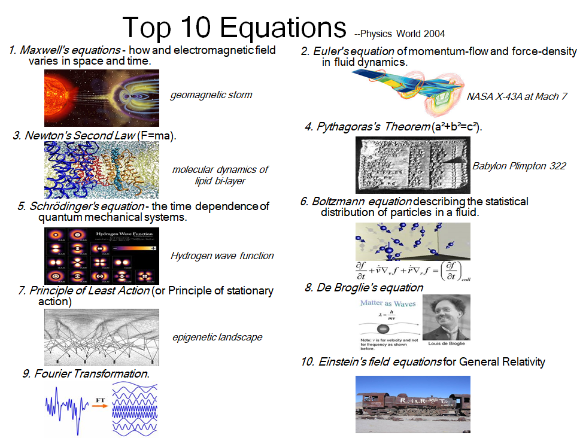

# Feng Kang

[figure not shown]

## “ A basic idea behind the design of numerical schemes is that they can preserve the properties of the original problems asmuch as possible...Different representations for the same physical law can lead to different computational techniques in solving the same problem, which can produce different numerical results...”

### Kang Feng (1920–1993)

-- Cited from a paper entitled “How to compute property Newton’s equation of motion

[[Symplectic spacewar from Cleve Moler]](https://blogs.mathworks.com/cleve/2012/06/19/symplectic-spacewar/) [[Java animations for symplectic algorithms]](https://www.unige.ch/~vilmart/java.html)

Cahn-Hilliard equation: phase separation of a binary fluid) $$ c_t = \Delta \big( c^3 - c - \gamma \Delta c \big) $$

```julia
using PyCall
YouTubeVideo = pyimport("IPython.lib.display").YouTubeVideo
Video = pyimport("IPython.display").Video;
```

[output not shown]

```julia
YouTubeVideo("MovUu2DwWvI")  # (Brian Wetton)
```

[video not shown]

Linear Wave equation $$ u_{tt} = \Delta u $$ models models many phenomen a of course, or, we can have fun and solve it on the [Stanford Bunny](https://graphics.stanford.edu/software/scanview/models/bunny.html) (see also similar works by [Colin MacDonald](https://www.math.ubc.ca/~cbm/)

```julia
YouTubeVideo("Bz8tT4-bV2w")
```

[video not shown]

### Reality -> Model -> Simulation -> Prediction

- Mathematical models of "real-world" processes (physics, chemistry, life sciences, engineering, ...) more often than not take the form of a system of ordinary or partial differential equations, integral equations, or closely related models. (sometimes stochastic, on networks, etc, but this is beyond the scope of this course)
- In this course we take the mathematical model as given and study how it is solved numerically.
- But we should not forget what the origin of the mathematical model is so that we are appreciative of the requirements.
  - the model is an approximation of reality, the numerical scheme is an approximation of the model.
  - how accurate is the model, i.e. how accurate should the numerical solution be?
  - how accurate are the model parameters?
  - are real-time simulations required?
  - long-time behaviour?
  - inverse and control problems?

A few important PDEs (there are many variations!)

- Laplace equation $$
  - \Delta u = f $$
- Heat equation $$ u_t - \Delta u = f $$
- Wave equation $$ u_{tt} - \Delta u = f $$
- Navier's equations : small-strain elasticity $$
  - \mu \Delta u + (\lambda+\mu) \nabla {\rm Div} u = f $$
- Nonlinear elastodynamics $$ u_{tt} = {\rm div} \Sigma(\nabla u) + f $$
- Navier-Stokes equations : incompressible viscous fluids $$ u_t + (u \cdot \nabla)u = \nu \Delta u - \nabla p, \quad {\rm Div} u = 0 $$
- Reaction-Diffusion systems
- Maxwell equation
- Einstein
- ...

```julia
# more fun examples of simulations on Youtube
YouTubeVideo("u8Kfn2o7epQ")    # Nonlinear elasticity - more from the Stanford bunny
YouTubeVideo("-kDb0HlDsIM")    # thermal convection in earth's mantle
YouTubeVideo("dbBmSBA7Kyw")    # spread of covid-19
YouTubeVideo("gxAaO2rsdIs")    # simulating the spread of an epidemic
YouTubeVideo("_0QhOCDzP4I&t")  # salt crystal melting in water
YouTubeVideo("jj0WsQYtT7M")    # NASA climate simulations
YouTubeVideo("rtBlZJ6gNiI")    # Predicting matter distribution in the universe
YouTubeVideo("bJX8fVsq5oQ")    # cf. e.g. Wachs, Frigard
YouTubeVideo("vOFcHqImXJ8")    # fun real-time NS
YouTubeVideo("hz7UjN_vYuw")    # flow past an airfoil - high resolution,
;
```

Brusselator: simple model for an autocatalytic reaction (arises also in enzymatic reactions, plasma and laser physics) $$\begin{aligned} u_t &= B + u^2 v - (A+1) u + \alpha \Delta u \\ v_t &= Au - u^2 v + \alpha \Delta v \end{aligned}$$

The embedded video will probably fail - [try this link instead](https://www.math.ubc.ca/~cbm/closestpoint/brusbunny.mpg)

```julia
# simulation on a surface using Steve Ruth and Colin Macdonald's closest point method
# Video(url="https://www.math.ubc.ca/~cbm/closestpoint/brusbunny.mpg", embed=true)
```

```julia
using DifferentialEquations
function f(u,p,t)
    return 1.0 - 3.0*t + u + t.^2 + t.*u
end
u0 = 0.0
tspan = (0.0,1.0)
prob = ODEProblem(f,u0,tspan)
sol = solve(prob,reltol=1e-7)
#sol = solve(prob,reltol=1e-6,saveat=0.1)
sol_Euler = solve(prob,Euler(),dt=.01)
```

[output not shown]

```julia
using Plots
plot(sol,linewidth=5,title="Solution to the linear ODE with a thick line",
     xaxis="Time (t)",yaxis="u(t)",label="Numerical Solution!") # legend=false
plot!(sol_Euler,linewidth=5,title="Euler solution", label="Euler Solution")
plot!(sol.t, t->t,lw=3,ls=:dash,label="Series Solution 1")
plot!(sol.t, t->t-t^2,lw=3,ls=:dash,label="Series Solution 2")
plot!(sol.t, t->t-t^2+1.0/3.0*t^3,lw=3,ls=:dash,label="Series Solution 3")
plot!(sol.t, t->t-t^2+1.0/3.0*t^3-1.0/6.0*t^4,lw=3,ls=:dash,label="Series Solution 4")
plot!(sol.t, t->t-t^2+1.0/3.0*t^3-1.0/6.0*t^4+1.0/30.0*t^5,lw=3,ls=:dash,label="Series Solution 5")
plot!(sol.t, t->t-t^2+1.0/3.0*t^3-1.0/6.0*t^4+1.0/30.0*t^5-1.0/45.0*t^6,lw=3,ls=:dash,label="Series Solution 6")
```

[output not shown]